# What is Iron Maiden, Taylor Swift and Pharrell Williams singing? A primer on text mining.[^1]

Walter Guillioli

April 04, 2025

## Introduction

I love music and data science. Purpose of this paper is to apply main text analytics techniques to explore lyrics from different authors.

We will see things like sentiment analysis, word clouds, topic model and network bigrams.

Purpose is to process lyrics and get idea of what they sign without reading lyrics.

## Data and Methods

48 songs were analyzed from these albums: Iron Maiden: Number of the Beast 9,  
Iron Maiden: X Factor 11, Pharrell Williams: GIRL 12, Taylor Swift: 1989 16.

Table 1 shows the names of the songs of each album.

```
## # A tibble: 48 × 3
##    artist      album               song
##    <chr>       <chr>               <chr>
##  1 Iron Maiden Number of the Beast Invaders
##  2 Iron Maiden Number of the Beast Children of the Damend
##  3 Iron Maiden Number of the Beast The Prisoner
##  4 Iron Maiden Number of the Beast 22 Acacia Avenue
##  5 Iron Maiden Number of the Beast The Number Of The Beast
##  6 Iron Maiden Number of the Beast Run to the Hills
##  7 Iron Maiden Number of the Beast Gangland
##  8 Iron Maiden Number of the Beast Hallowed be thy Name
##  9 Iron Maiden Number of the Beast Total Eclipse
## 10 Iron Maiden X Factor            Sign of the Cross
## # ℹ 38 more rows
```

```
## # A tibble: 48 × 1
##    song
##    <chr>
##  1 Invaders
##  2 Children of the Damend
##  3 The Prisoner
##  4 22 Acacia Avenue
##  5 The Number Of The Beast
##  6 Run to the Hills
##  7 Gangland
##  8 Hallowed be thy Name
##  9 Total Eclipse
## 10 Sign of the Cross
## # ℹ 38 more rows
```

The lyrics were split into invidual words for analysis and common words (stop words) like a, on, the were removed. Table 2 shows number of words for analysis:

| artist_album | number_of_words |
| --- | --- |
| Iron Maiden: Number of the Beast | 800 |
| Iron Maiden: X Factor | 871 |
| Pharrell Williams: GIRL | 1437 |
| Taylor Swift: 1989 | 2000 |

## Results

### Top words used on the lyrics

We can start by plotting the top 10 most common words across all albums.

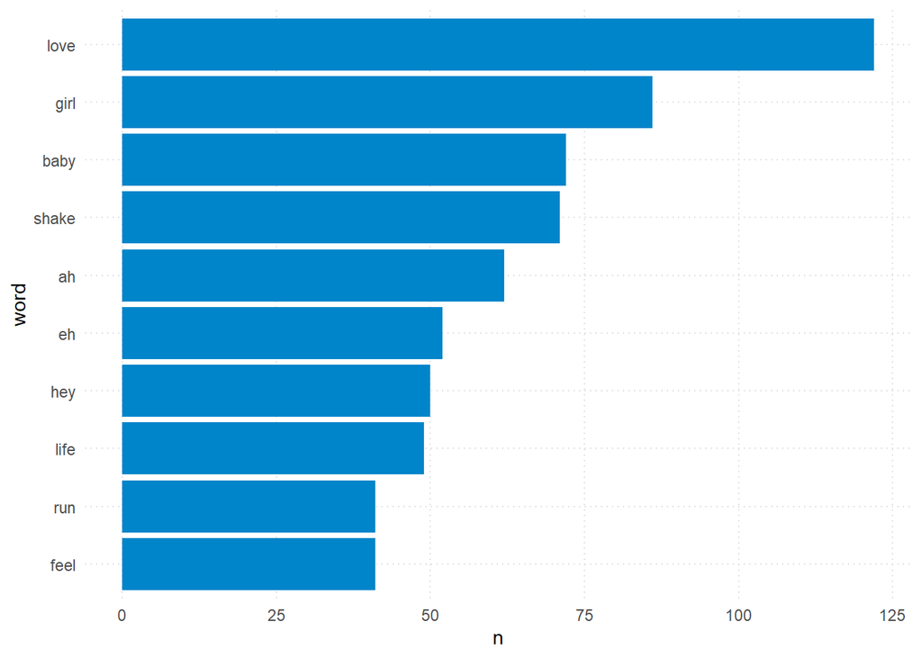

This is relatively interesting but not useful since we know some artists use more words than others. So let’s do the same but by album.

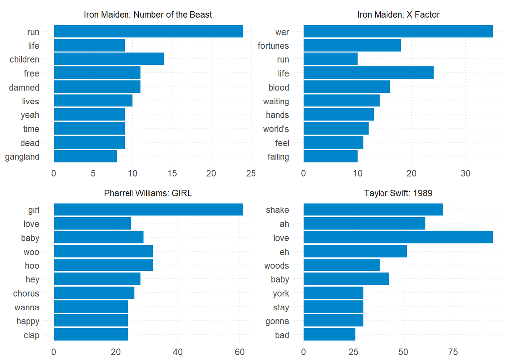

Alternative we could use a more advanced way via tfidf and these are the results. so discuss and pick one and / or send one to appendix.

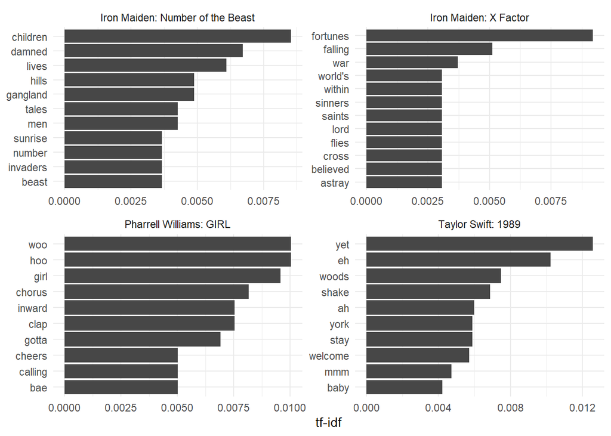

### Sentiment evolution in the album

The top words above give an idea of what they talk about but it’s just the start. The next thing is to see if they sing about happy, sad or angry stuff. Probably a bit of everything.

We start with a simple analysis to see if the sentiment is positive or negative. In the chart below we see the sentiment evolution of the albums as the album progress where each bar represents a line in the song. Also note that number of lines varies and Maiden sings with less words.

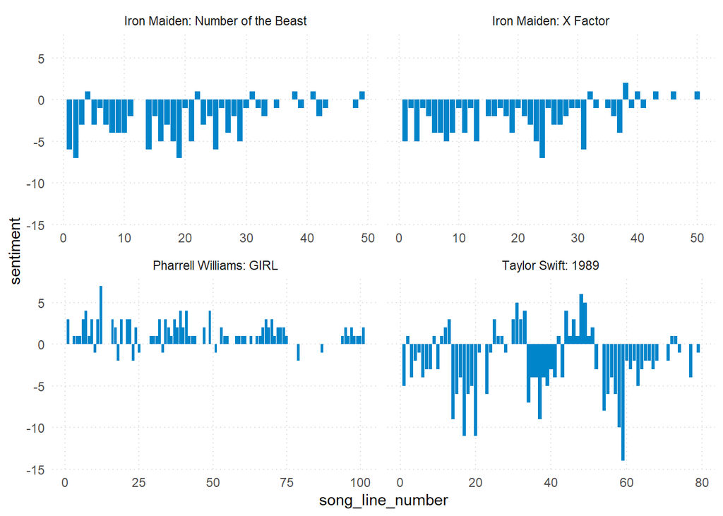

Several points to highlight from this chart. Iron Maiden tends to be very negative while Taylor Swift is mostly negative with some exceptions. Pharrell Williams on the contrary seems to be a very happy and uplifting singer. We will explore why and more in the next section.

### Main feelings from each album

Another thing we can do is to see the sentiment for each album. Maiden is motly about fear, sadness and anger. While Pharrell sings about Joy and Trust. While Taylor seems to be happier but sometimes is inundated with sadness and fear. As we will see later this is a diffrent fear than the one Maiden shows.

| artist_album | sentiment | n |
| --- | --- | --- |
| Iron Maiden: Number of the Beast | fear | 109 |
| Iron Maiden: Number of the Beast | anger | 81 |
| Iron Maiden: Number of the Beast | sadness | 78 |
| Iron Maiden: Number of the Beast | anticipation | 56 |
| Iron Maiden: Number of the Beast | trust | 42 |
| Iron Maiden: X Factor | fear | 143 |
| Iron Maiden: X Factor | sadness | 100 |
| Iron Maiden: X Factor | anger | 83 |
| Iron Maiden: X Factor | trust | 72 |
| Iron Maiden: X Factor | anticipation | 68 |

[output cut: 10 more lines]

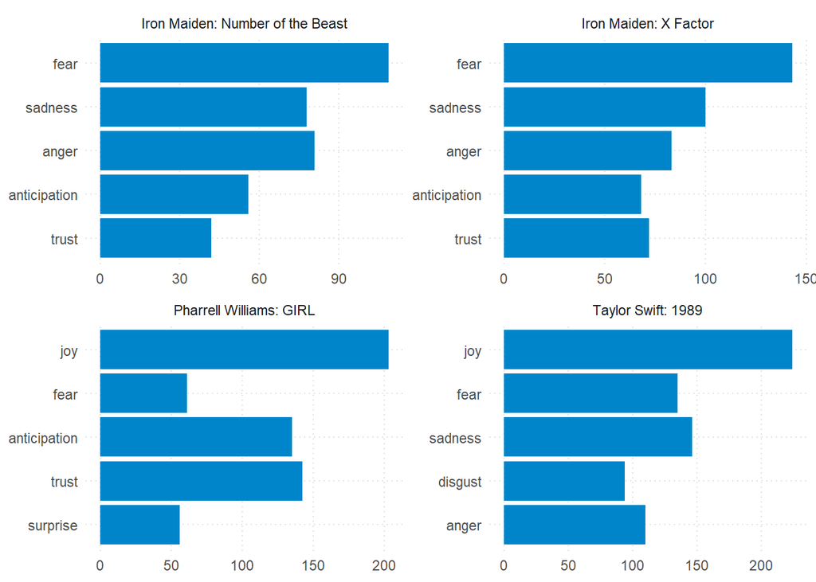

### What are they afraid of?

A common feeling across all albums is the sentiment of fear. So next we explore the top fear words of each album.

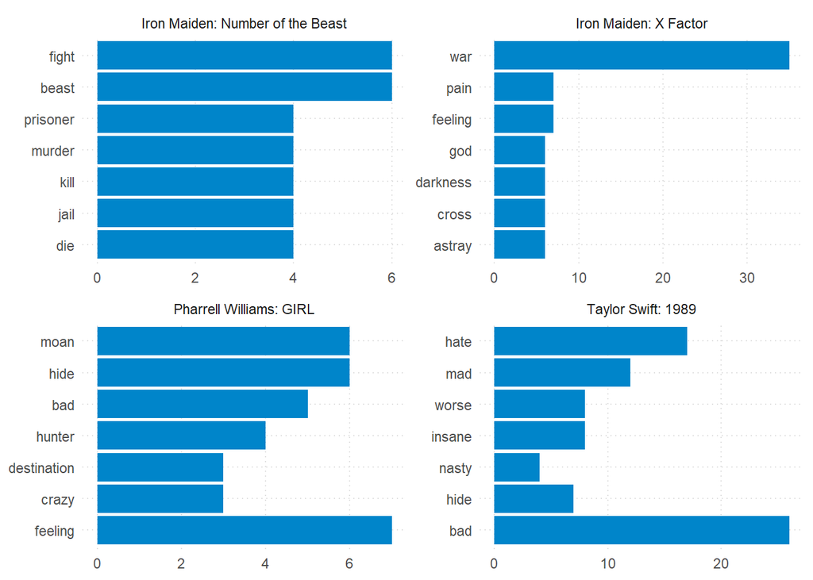

So even though they are all fear words, the meaning is different. TAke Iron Maiden is talking about fight, kill, murder, beast, war. Whille Pharrell talks about his feelings and moan. Even though hunter appears it’s a love song about hunting for his girl. Taylor swift with bad, hate and mad clearly is talking about a bad romance.

### Positive and negative words

Exploring the words further we can take a look at the most positive and negative words per album.

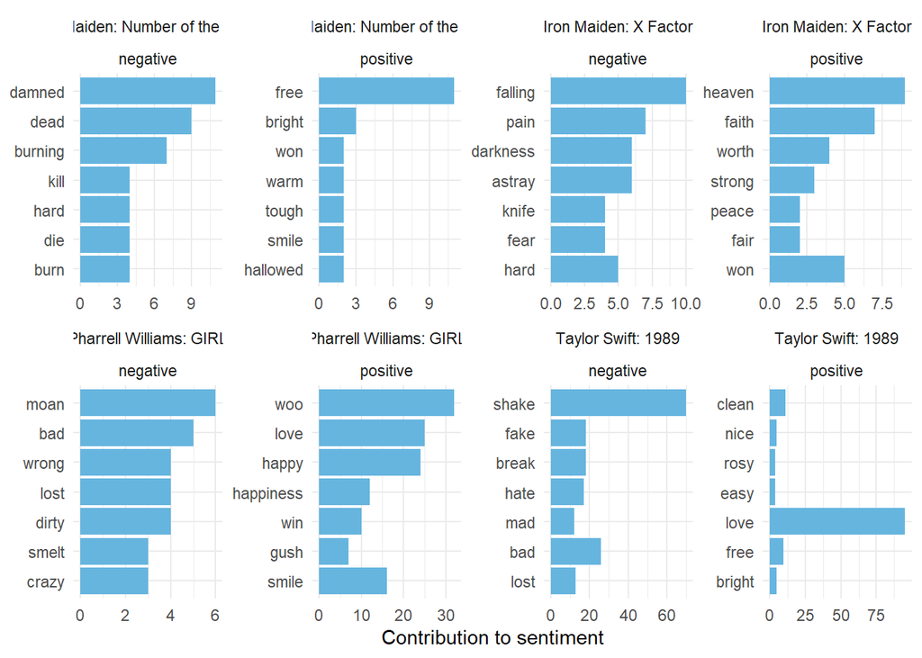

```
## [1] 1
```

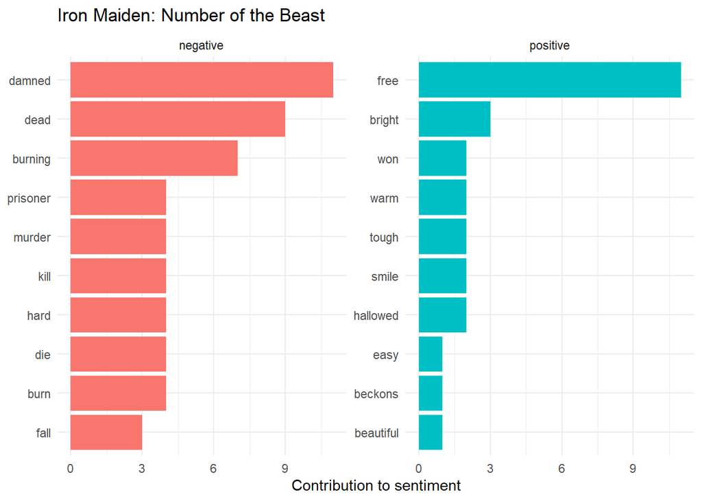

```
## [1] 2
```

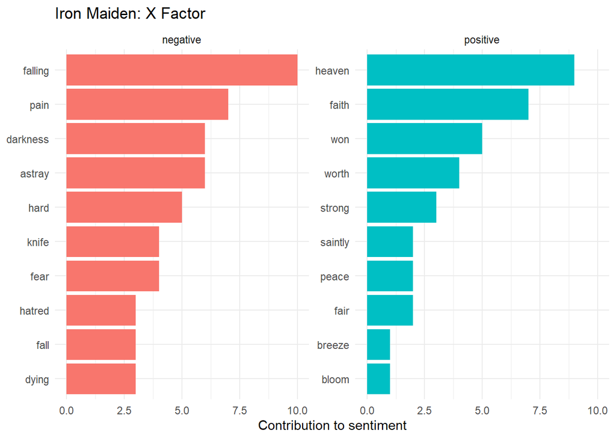

```
## [1] 3
```

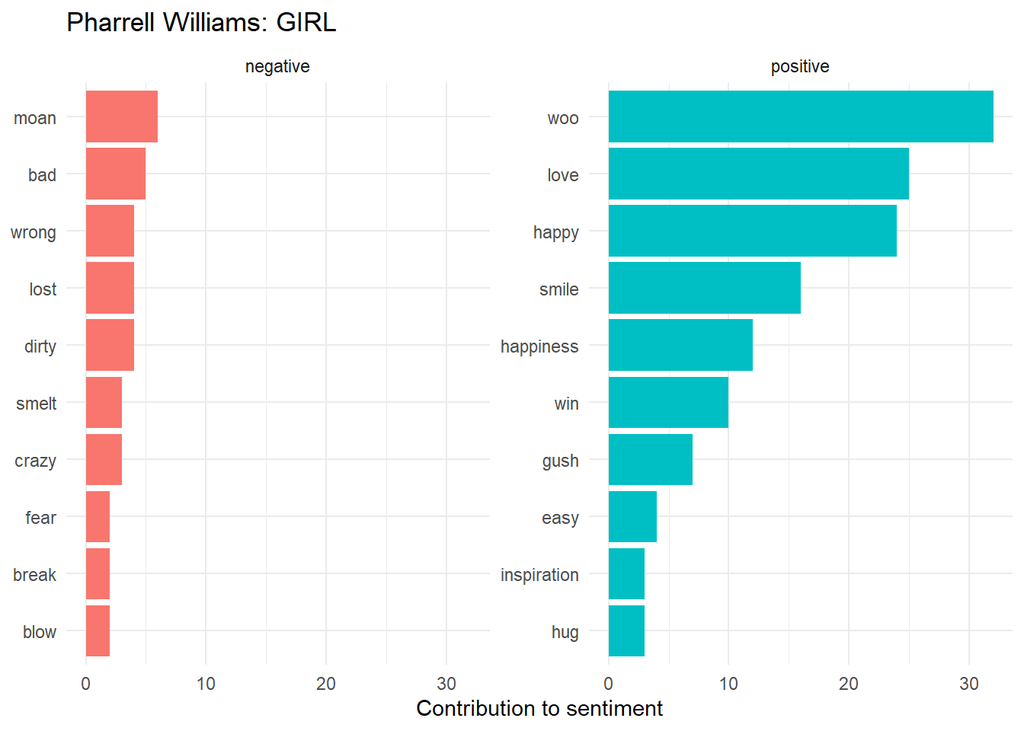

```
## [1] 4
```

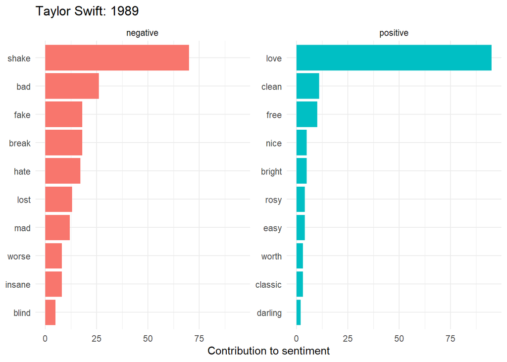

Maiden best is interesting. Free is positive but it’s actually from running free and it’s someone escaping from the police. Hallowed is also from a song called hallowed by the name from someone on death row. so this can be misleading.

Pharrell, appreciate positivism with woo (part of woo-hoo) and in general talks about happiness. Moan comes from sex so huhh.

Taylor we can see that likes to talk about love - good or bad? and shake is that from shake what? can be from shake the body soo…

### How negative is each song?

A next obvious quesitno is beyond words. How does each song contribute to the feelings shows above. For that we calculate a negative ratio of each song which is basically # of negative words over total words so a higher number means a negative song. results are this.

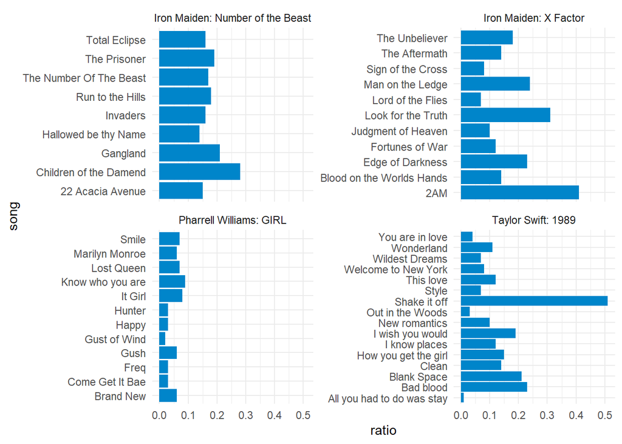

Makes sense for Maiden cause Chilre of damned talks about homeless kids and 2am talks about contemplating suicidine.

Not surpriseing Williams is an optimistic fellow.

And Taylow, Shake it off, is misleading cause it’s not a negative song. it’s more about somebody that likes to go out and party and “shakes off” criticisim from others so could be positive. example fo limitation. next is bad blood, which is about a failed relatioship that went from love to hate so it makes sense.

### Looking beyond one word

As seen, one word is limited so here we look at combinations of two words that give more context. So what are the top 10 combinations of pairs of words per album?

| bigram | n |
| --- | --- |
| i i | 99 |
| of the | 90 |
| in the | 89 |
| are we | 68 |
| out of | 61 |
| i wish | 59 |
| and i | 55 |
| this love | 52 |
| oh oh | 50 |
| yet are | 43 |

[output cut: 7131 more lines]

| word1 | word2 | n |
| --- | --- | --- |
| ah | ah | 41 |
| girl | girl | 41 |
| eh | eh | 40 |
| woo | hoo | 32 |
| shake | shake | 28 |
| happy | clap | 24 |
| bad | blood | 18 |
| baby | woo | 16 |
| calling | woo | 16 |
| break | break | 12 |

[output cut: 741 more lines]

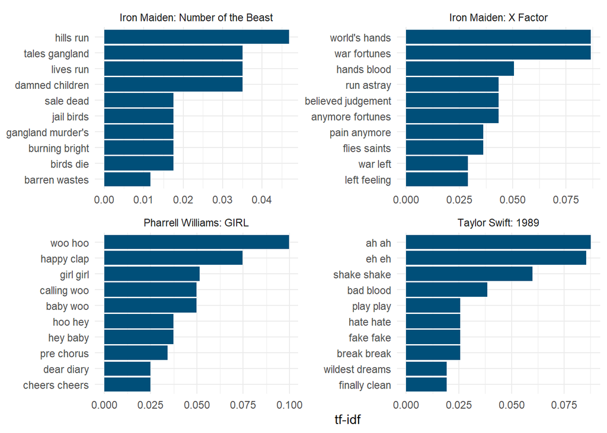

### Network graphs of these bigrams

naturally we want to see how these words are interconnected to see about topics they talk about.

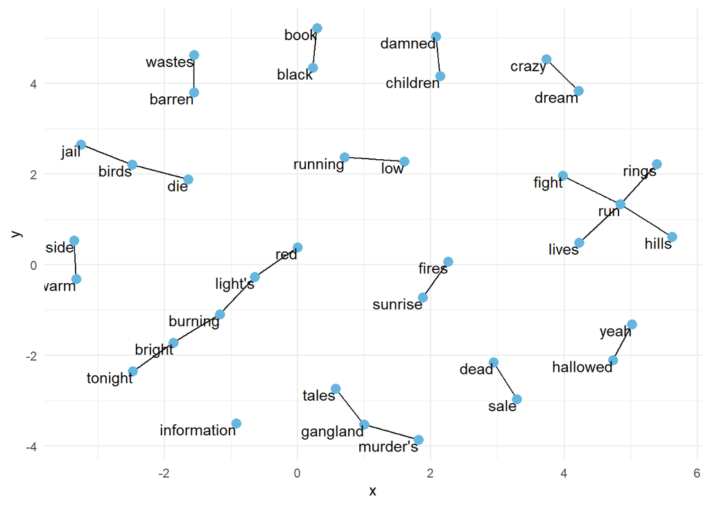

```r
plot_graph(albums_to_parse[1], 1)
```

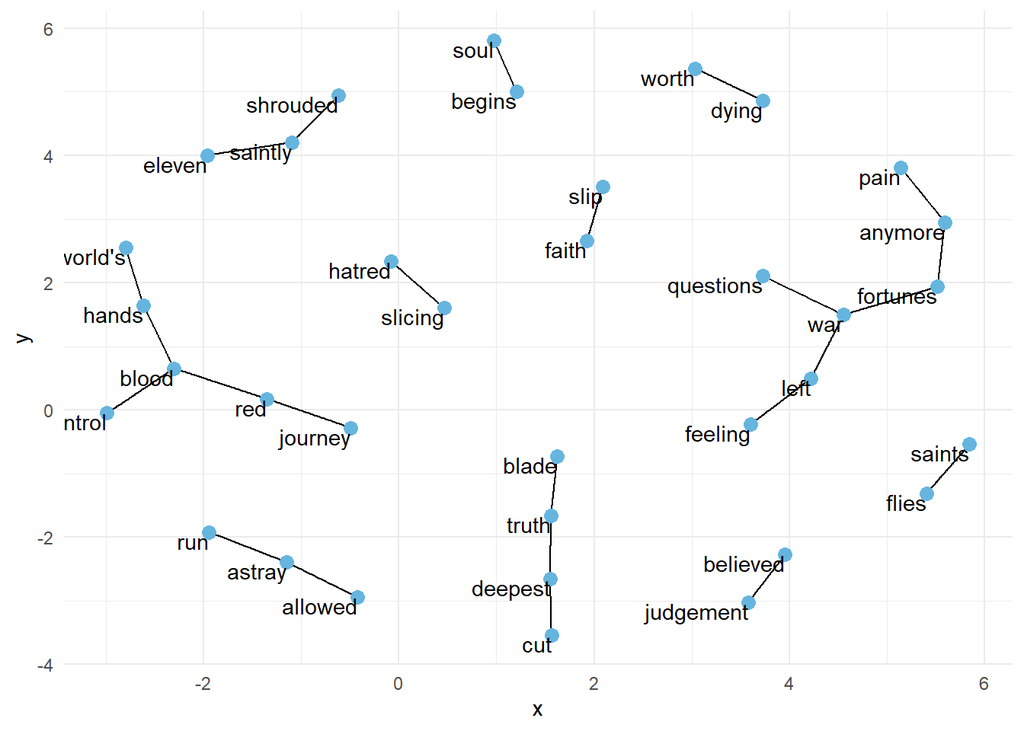

```r
plot_graph(albums_to_parse[2], 1)
```

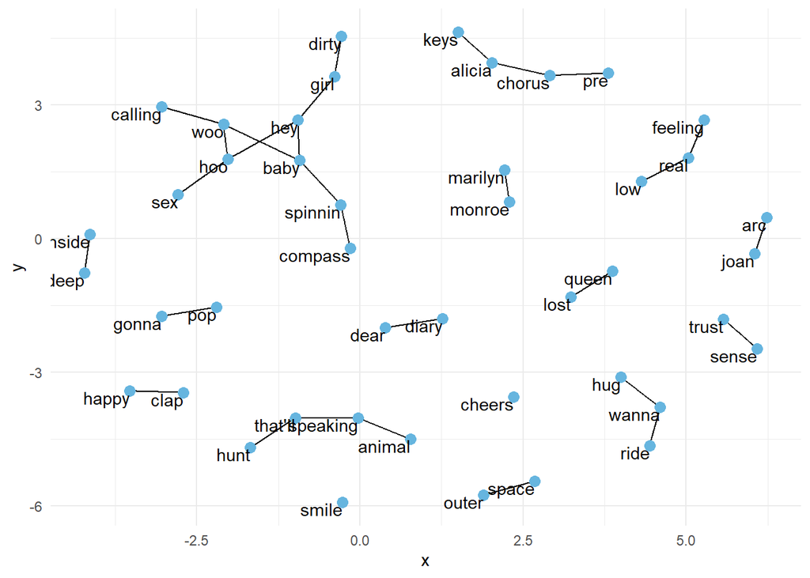

```r
plot_graph(albums_to_parse[3], 2)
```

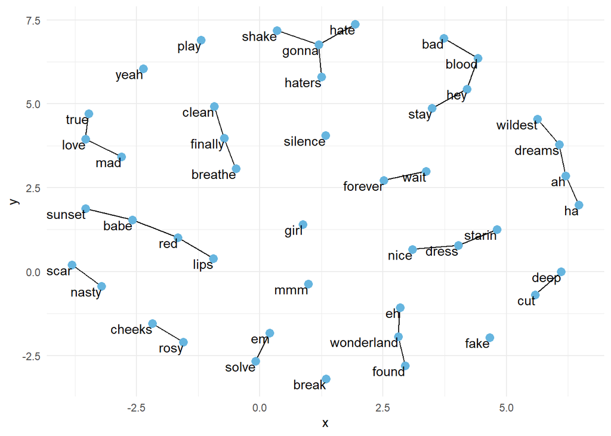

```r
plot_graph(albums_to_parse[4], 3)
```

taylor, she talks about all she;s gonna do as is shake. but more context is needed cause paople are gonna hate her. another interesting, is she’s asking about stay with someone with bad blood.

for williams we can see girl connected to dirty gilr and hey girl and hey baby so sounds about happy love. he also wants to hug.

Maiden beast, see how more context is given. run is connected to varios words and when reading the lyrics one can see that its about running to the hills (escaping), and run for your lives (escaping).

### Impact of hegated words

Another importantthing to consider is that happy when doing one word is treated as positive so let’s say “i am happy” and “i am not happy” will read happy and that is that. so that is why combining two words give context. so it’s intersting to see what words were kind of misclassified with negated words before. so i see what words were c(“not”, “no”, “never”, “without”) after thse ones and how much they misled the scores.

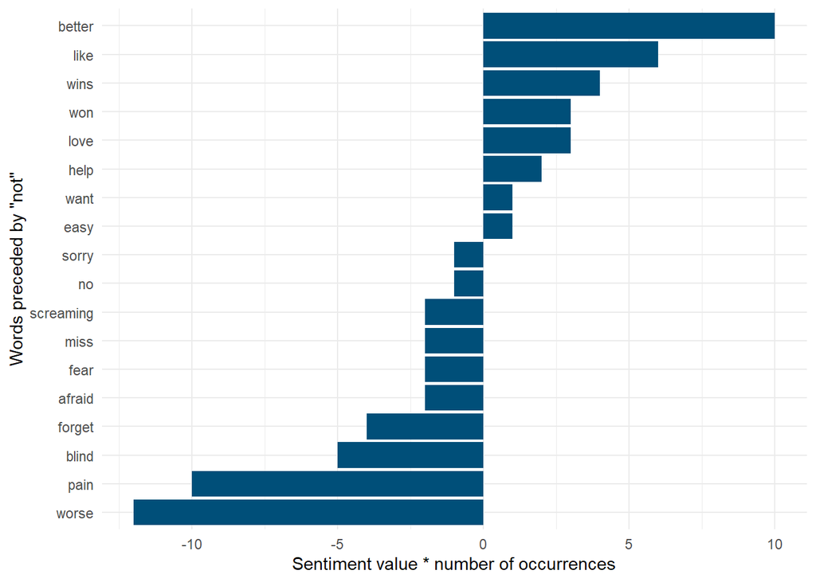

so for example, worse its the most negative here. but how about it say i am not worse, that would kind of be positive.

let’s take like, if it’s never like then we have a problem.

### Topic modeling

Finally imagine we didn’t have the albums. we just knew songs. well there is a way to group them by “topic”. so I ovbiously tune the algo to 4 topics.

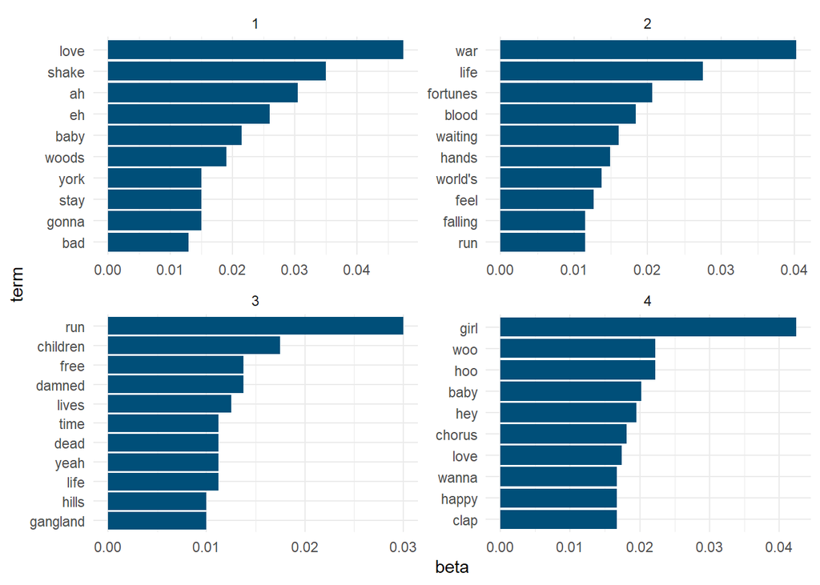

if I compre this charts with above it would be easy to identify the 4 albums with these 4 topics.

## Conclusions

1. one word analysis can be misleading

## Appendix

[^1]: The data and scripsts posted here: https://github.com/wguillioli